# Coursework Report

*N* removed NAs: 2

*N* removed typo: 1

*N* removed <18: 22

*N* total clean: 125

| Group | *N* | *M*<sub>age</sub> | *M*<sub>rating</sub> |
| --- | --- | --- | --- |
| Control | 55 | 21.1 | 6.2 |
| Experim | 70 | 20.9 | 5.3 |

**Main analysis results**

*t*(123) = 7.44, *p* < .001

[interactive chart not shown]

[figure not shown]

[interactive chart not shown]

# Coursework Report

Analysing Data, Spring 2020

```
## tibble [150 x 6] (S3: tbl_df/tbl/data.frame)
##  $ id        : Factor w/ 150 levels "ACJP","AEUN",..: 12 98 109 54 131 52 86 117 46 58 ...
##  $ age_years : chr [1:150] "18" "20" "24" "17" ...
##  $ condition : Factor w/ 3 levels "contol","control",..: 3 3 3 3 3 3 3 3 3 3 ...
##  $ question_1: num [1:150] 4 4 4 8 6 7 6 4 8 6 ...
##  $ question_2: num [1:150] 6 5 7 7 4 5 4 4 5 5 ...
##  $ question_3: num [1:150] 5 5 7 6 7 5 4 5 5 4 ...
```

```
##        id       age_years                condition    question_1    question_2     question_3
##  ACJP   :  1   Length:150         contol      : 1   Min.   :3.0   Min.   :1.00   Min.   :2.00
##  AEUN   :  1   Class :character   control     :69   1st Qu.:5.0   1st Qu.:5.00   1st Qu.:5.00
##  ALHZ   :  1   Mode  :character   experimental:80   Median :6.0   Median :6.00   Median :6.00
##  AOCJ   :  1                                        Mean   :5.9   Mean   :5.69   Mean   :5.69
##  AOLV   :  1                                        3rd Qu.:7.0   3rd Qu.:7.00   3rd Qu.:7.00
##  ASKQ   :  1                                        Max.   :9.0   Max.   :9.00   Max.   :9.00
##  (Other):144
```

```
## # A tibble: 1 x 4
##   mean_age_1 sd_age_1 min_age_1 max_age_1
##        <dbl>    <dbl> <chr>     <chr>
## 1         NA     3.23 11        4
```

```
## .
##  4 11 13 14 15 16 17 18 19 20 21 22 23 24 25 26 27 28 29
##  1  1  1  1  2  8  8 23 16 19 19 19  9  8  7  2  1  1  1
```

```
## # A tibble: 150 x 6
##    id    age_years condition question_1 question_2 question_3
##    <lgl> <lgl>     <lgl>     <lgl>      <lgl>      <lgl>
##  1 FALSE FALSE     FALSE     FALSE      FALSE      FALSE
##  2 FALSE FALSE     FALSE     FALSE      FALSE      FALSE
##  3 FALSE FALSE     FALSE     FALSE      FALSE      FALSE
##  4 FALSE FALSE     FALSE     FALSE      FALSE      FALSE
##  5 FALSE TRUE      FALSE     FALSE      FALSE      FALSE
##  6 FALSE FALSE     FALSE     FALSE      FALSE      FALSE
##  7 FALSE FALSE     FALSE     FALSE      FALSE      FALSE
##  8 FALSE TRUE      FALSE     FALSE      FALSE      FALSE
##  9 FALSE FALSE     FALSE     FALSE      FALSE      FALSE
## 10 FALSE FALSE     FALSE     FALSE      FALSE      FALSE
## # ... with 140 more rows
```

```
## [1] 22
```

```
## .
## 18 19 20 21 22 23 24 25 26 27 28 29
## 23 16 19 19 19  9  8  7  2  1  1  1
```

```
## tibble [125 x 6] (S3: tbl_df/tbl/data.frame)
##  $ id        : Factor w/ 150 levels "ACJP","AEUN",..: 12 98 109 52 86 46 58 30 44 116 ...
##  $ age_years : num [1:125] 18 20 24 21 23 23 20 18 23 19 ...
##  $ condition : chr [1:125] "experimental" "experimental" "experimental" "experimental" ...
##  $ question_1: num [1:125] 4 4 4 7 6 8 6 6 4 6 ...
##  $ question_2: num [1:125] 6 5 7 5 4 5 5 4 6 5 ...
##  $ question_3: num [1:125] 5 5 7 5 4 5 4 4 5 5 ...
```

```
## [1] 125
```

```
## # A tibble: 1 x 4
##    mean    sd   min   max
##   <dbl> <dbl> <dbl> <dbl>
## 1    21  2.42    18    29
```

```
## $mean
## [1] 21
##
## $sd
## [1] 2.42
##
## $min
## [1] 18
##
## $max
## [1] 29
```

```
## # A tibble: 2 x 5
##   condition    mean_age sd_age min_age max_age
##   <chr>           <dbl>  <dbl>   <dbl>   <dbl>
## 1 control          21.1   2.43      18      29
## 2 experimental     20.9   2.43      18      28
```

Table : Summary of Mean Ratings by Item and Condition

| condition | mean_rate | sd_rate | mean_rate2 | sd_rate2 | mean_rate3 | sd_rate3 |
| --- | --- | --- | --- | --- | --- | --- |
| control | 6.24 | 1.37 | 6.25 | 1.28 | 6.11 | 1.34 |
| experimental | 5.40 | 1.10 | 5.29 | 1.08 | 5.20 | 1.27 |

Table 1 : Summary of Participant descriptives by experimental condition

| condition | mean_age | sd_age | min_age | max_age |
| --- | --- | --- | --- | --- |
| control | 21.1 | 2.43 | 18 | 29 |
| experimental | 20.9 | 2.43 | 18 | 28 |

```
##        id        age_years   condition           question_1     question_2     question_3
##  ACJP   :  1   Min.   :18   Length:125         Min.   :3.00   Min.   :2.00   Min.   :2.0
##  AEUN   :  1   1st Qu.:19   Class :character   1st Qu.:5.00   1st Qu.:5.00   1st Qu.:5.0
##  ALHZ   :  1   Median :21   Mode  :character   Median :6.00   Median :6.00   Median :6.0
##  AOCJ   :  1   Mean   :21                      Mean   :5.77   Mean   :5.71   Mean   :5.6
##  AOLV   :  1   3rd Qu.:22                      3rd Qu.:7.00   3rd Qu.:7.00   3rd Qu.:7.0
##  AVTS   :  1   Max.   :29                      Max.   :9.00   Max.   :9.00   Max.   :9.0
##  (Other):119
```

Table 2 Description of mean ratings by condition

| Condition | *M*<sub>question1</sub> | *SD*<sub>question1</sub> | *M*<sub>question2</sub> | *SD*<sub>question2</sub> | *M*<sub>question3</sub> | *SD*<sub>question3</sub> | *M*<sub>attract</sub> | *SD*<sub>attract</sub> |
| --- | --- | --- | --- | --- | --- | --- | --- | --- |
| control | 6.24 | 1.37 | 6.25 | 1.28 | 6.11 | 1.34 | 6.2 | 0.76 |
| experimental | 5.40 | 1.10 | 5.29 | 1.08 | 5.20 | 1.27 | 5.3 | 0.60 |

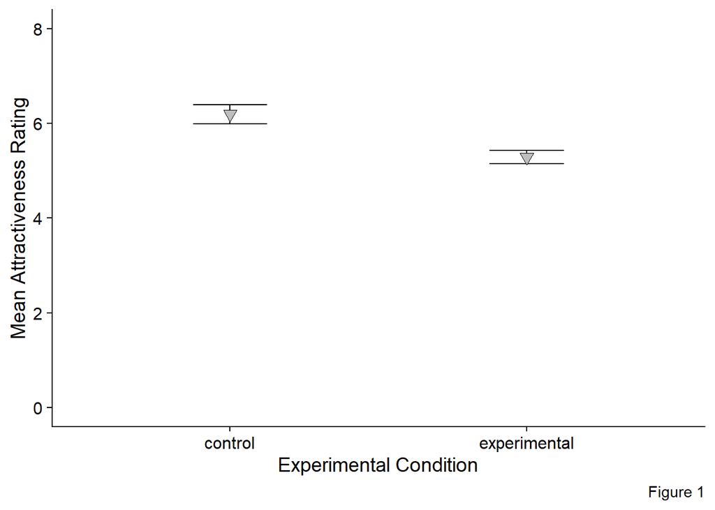

```
##
##  Two Sample t-test
##
## data:  attract_mean by condition
## t = 7, df = 123, p-value = 0.00000000002
## alternative hypothesis: true difference in means is not equal to 0
## 95 percent confidence interval:
##  0.664 1.145
## sample estimates:
##      mean in group control mean in group experimental
##                        6.2                        5.3
```

# Methods

## Participants

Table 1 : Summary of Participant descriptives by experimental condition

| condition | mean_age | sd_age | min_age | max_age |
| --- | --- | --- | --- | --- |
| control | 21.1 | 2.43 | 18 | 29 |
| experimental | 20.9 | 2.43 | 18 | 28 |

## Design

The column “age_years” was classified as characters and was changed to numeric. A tibble, `mean_attract_total`, had a mean score for each question separated by condition and the standard deviation for each question. This can be seen in Table 2.

Table 2 Description of mean ratings by condition

| Condition | *M*<sub>question1</sub> | *SD*<sub>question1</sub> | *M*<sub>question2</sub> | *SD*<sub>question2</sub> | *M*<sub>question3</sub> | *SD*<sub>question3</sub> | *M*<sub>attract</sub> | *SD*<sub>attract</sub> |
| --- | --- | --- | --- | --- | --- | --- | --- | --- |
| control | 6.24 | 1.37 | 6.25 | 1.28 | 6.11 | 1.34 | 6.2 | 0.76 |
| experimental | 5.40 | 1.10 | 5.29 | 1.08 | 5.20 | 1.27 | 5.3 | 0.60 |

The higher the score under each question, the more attractive the female participants perceived the photograph. The mean score for each question was consistently higher for the control condition compared to the experimental condition meaning overall, the control had a higher rating. However the standard deviations were consistently higher for the control condition across all the questions which means there was more variability in the range of scores compared to the experimental condition. The statistical analysis that was used was a two-sample T test.

```
##
##  Two Sample t-test
##
## data:  attract_mean by condition
## t = 7, df = 123, p-value = 0.00000000002
## alternative hypothesis: true difference in means is not equal to 0
## 95 percent confidence interval:
##  0.664 1.145
## sample estimates:
##      mean in group control mean in group experimental
##                        6.2                        5.3
```

The average of the experimental group and the control group is is follows: (*M*<sub>white</sub>= 6.2; *M*<sub>red</sub> = 5.3) The independent t-test conducted found that the results are significant.

(*M*<sub>diff</sub> = 0.9), 95% CI [0.66, 1.15], *t*(123) = 7.44, *p* = < 0.001) Furthermore, a graph was made to illustrate the relationship between mean attractiveness rating and experimental condition including the confidence intervals.

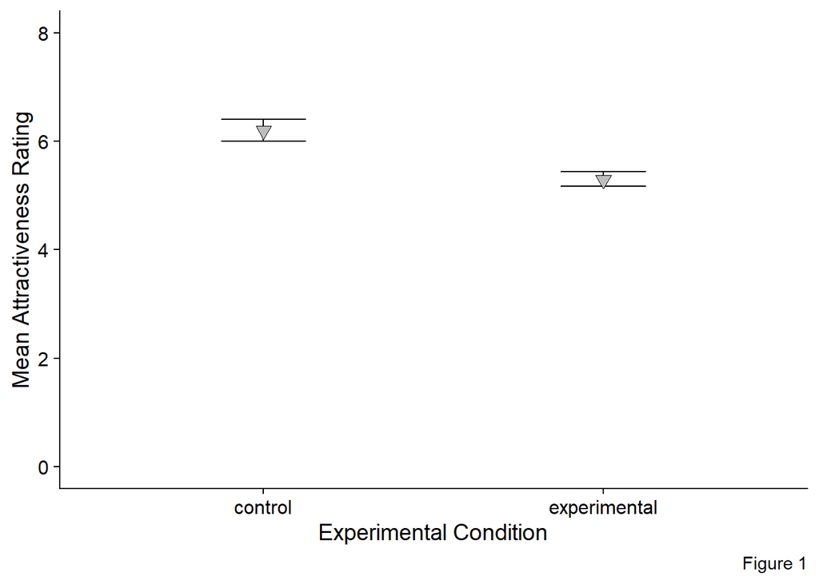

# Discussion

There was a statistically significant result however it wasn’t what our hypothesis predicted. Our hypothesis predicted that the experimental condition (red background) would receive the higher attractiveness ratings than the control (white background) but it was the white condition that got this. Therefore, we may accept the conceptual hypothesis that color does influence attractiveness, but not the color red as found by Elliot et al (2010).

The strengths of this study is that it is a close replication of the Elliot et al (2010) study, thus allowing us to investigate if the red effect is a genuine contributing factor when it comes to men attracting women. Furthermore, R studio was used which aids the promotion of open and reproducible science by allowing other scientists and students see the exact method of analysis. We also used a stringent p- value of 0.001 to ensure that the results was statistically highly significant. Limitations of the present study is that it does not consider other factors that may contribute to attraction. There is evidence that smart clothing can lead to higher attractiveness ratings compared to casual clothing (Hesslinger, Goldbach & Carbon, 2015). There are also the role of pheromones (Grammer, Fink & Neave, 2005) and body language (Clore et al, 1975). The photograph may not have ecological validity as it does not reflect the variability of attractiveness that exists in the real world.  
Some studies however do give some weight to the red effect including a study done by Roberts, Owen & Havlicek (2010) which found that men wearing red shirts were rated more highly on a attractiveness scale. Also Stephen et al (2012) found that female participants increased the redness of of men (photographs) which was correlated with higher levels of attraction. Due to the various findings,it is hard to judge whether red makes men more attractive.

In the above studies, there are extraneous variables like clothing, lighting etc. Furthermore, there is no value in clinical psychology to study the red effect, it contributes nothing to the understanding and treatment of disorders. It also does not contribute to our collective understanding of human behavior or cognition. The red effect should be however studied within the realm of animal and evolutionary psychology as it would give us insight into mating behavior. Future studies could focus the change in mating behavior of birds and baboons if the red coloration was replaced with white (Andersson & Iwasa, 1996). This present study found that the red background) did not lead to a higher attraction. This was opposite to what was found by Elliot et al (2010). From this and other research, it is difficult to conclude whether the red effect exists in humans. There are studies that both confirm and reject this notion according to their findings. There is no effective contribution to clinical psychology however the study of the red effect may have its place in evolutionary and animal psychology.

# Reference

Andersson, M., & Iwasa, Y. (1996). Sexual selection. Trends In Ecology & Evolution, 11(2), 53-58. doi: 10.1016/0169-5347(96)81042-1

Clore, G., Wiggins, N., & Itkin, S. (1975). Judging attraction from nonverbal behavior: The gain phenomenon. Journal Of Consulting And Clinical Psychology, 43(4), 491-497. doi: 10.1037/h0076847

Elliot, A., Niesta Kayser, D., Greitemeyer, T., Lichtenfeld, S., Gramzow, R., Maier, M., & Liu, H. (2010). Red, rank, and romance in women viewing men. Journal Of Experimental Psychology: General, 139(3), 399-417. doi: 10.1037/a0019689

Francis, G. (2013). Publication bias in “Red, rank, and romance in women viewing men,” by Elliot et al. (2010). Journal Of Experimental Psychology: General, 142(1), 292-296. doi: 10.1037/a0027923

Grammer, K., Fink, B., & Neave, N. (2005). Human pheromones and sexual attraction. European Journal Of Obstetrics & Gynecology And Reproductive Biology, 118(2), 135-142. doi: 10.1016/j.ejogrb.2004.08.010

Hesslinger, V., Goldbach, L., & Carbon, C. (2015). Men in red: A reexamination of the red-attractiveness effect. Psychonomic Bulletin & Review, 22(4), 1142-1148. doi: 10.3758/s13423-015-0866-8

Milinski, M., & Bakker, T. (1990). Female sticklebacks use male coloration in mate choice and hence avoid parasitized males. Nature, 344(6264), 330-333. doi: 10.1038/344330a0

Peperkoorn, L., Roberts, S., & Pollet, T. (2016). Revisiting the Red Effect on Attractiveness and Sexual Receptivity. Evolutionary Psychology, 14(4), 147470491667384. doi: 10.1177/1474704916673841

Roberts, S., Owen, R., & Havlicek, J. (2010). Distinguishing between Perceiver and Wearer Effects in Clothing Color-Associated Attributions. Evolutionary Psychology, 8(3), 147470491000800. doi: 10.1177/147470491000800304

Stephen, I., Oldham, F., Perrett, D., & Barton, R. (2012). Redness Enhances Perceived Aggression, Dominance and Attractiveness in Men’s Faces. Evolutionary Psychology, 10(3), 147470491201000. doi: 10.1177/147470491201000312

Waitt, C., Little, A., Wolfensohn, S., Honess, P., Brown, A., Buchanan-Smith, H., & Perrett, D. (2003). Evidence from rhesus macaques suggests that male coloration plays a role in female primate mate choice. Proceedings Of The Royal Society Of London. Series B: Biological Sciences, 270(suppl_2). doi: 10.1098/rsbl.2003.0065